# Lab 2: Bayesian Updating and Simulation

Author

Dr. Irene Vrbik

# Introduction

“Statistical inference is the process of extracting information about an unknown variable or an unknown model from available data” (Bertsekas & Tsitsiklis, 2008). Bayesian inference is a method of statistical inference in which unknown parameters of interest are treated as random variables. This week in lecture we have discussed some of the fundamental concepts of probability. Recall Bayes Theorem:
$$\begin{align}
P(A\mid B) &= \frac{ P(B\mid A) P(A)}{ P(B)}
\end{align}$$
Expressed in terms of probability distributions we have:
$$\begin{align}
p(x\mid y) &= \frac{ p(y\mid x) p(x)}{ p(y)}
\end{align}$$

Note that I will be using $P(E)$ to denote probabilities statements of an event $E$ and $p(x)$ to denote probability distributions; either Probability Mass Function (PMF) in the discrete case or Probability Density Function (PDF) in the continuous case. Recall the following definitions:

## Probability Mass Function (PMF)

If $X$ is a discrete random variable, thefunction given by $p(x)=P(X=x)$ for each $x$ within the range (or support denoted $S_x$) of $X$ is called the probability distribution or **probability mass function** (or **pmf**) of $X$. A valid pmf must have the following properties:

1. $p(x)=P(X=x) > 0$ if $x \in$ the support $S_x$
2. $\sum_{x \in S_x}p(x)=1$

## Probability Density Function (PDF)

A function with values $p(x)$, defined over the set of all real numbers, is called a **probability density function** (or **pdf**) of continuous random variable $X$ if and only if
$$P(a \leq X \leq b) = \int_{a}^bp(x)dx.$$
for any real constants $a$ and $b$ with $a \leq b$. A function can serve as a probability density of a continuous random variable $X$ if its values, $p(x)$, satisfy the conditions

1. $p(x)\geq 0$, for $-\infty < x <\infty$.
2. $\int_{-\infty}^{\infty} p(x) dx =1$.

## Marginal Distribution

Given a known joint distribution of two discrete random variables, say, $X$ and $Y$, the **marginal distribution** of $X$, denoted $p(X)$ is the probability distribution of $X$ when the values of $Y$ are not taken into consideration. This can be calculated by summing the joint probability distribution over the support of $Y$ denoted here by $S_y$.
$$\begin{align}
p(x)&=\sum _{y \in S_y}p(x,y) = \sum _{j}p(x\mid y)p(y) & \text{for discrete random variables}\\
p(x)&=\int _{y}p(x,y) dy & \text{for continuous random variables}
\end{align}$$

## Bayesian Framework

In the Bayesian framework we will be treating $\theta$, the parameter of interest, as a *random variable*. The goal of Bayesian statistics is “to represent prior uncertainty about model parameters with a probability distribution and to update this prior uncertainty with current data to produce a posterior probability distribution for the parameter that contains less uncertainty” (Lynch, 2007). More formally, we have the following relationship in the Bayesian framework:
$$\begin{align}
p(\theta \mid x)&= \frac{p(x \mid \theta)p(\theta)}{{p(x)}}
\end{align}$$
Each of this terms will be refered to by a special name:
$$\begin{align}
\text{posterior} &= \frac{\text{likelihood} \cdot \text{prior}}{\text{evidence}} \\
\text{posterior} &\propto {\text{likelihood} \cdot \text{prior}}
\end{align}$$
The second line is our so-called *unnormalized posterior*. By that we mean this does not satisfy the conditions of a “proper” distribution as outlined above; namely the unnormalized posterior, does not integrate to 1 (in the case of continuous $\theta$), our sum to 1 over the support or $\theta$ (in the case of discrete $\theta$).

Bayesian inference combines the subjective belief of model parameter $\theta$ (as summarized by the prior distribution, $p(\theta)$) with evidence from the data (i.e. the likelihood $p(x \mid \theta)$) to produce a posterior distribution which contains less uncertainty[^1] about $\theta$. This is differs from the classical Frequentist paradigm, wherein only the likelihood has meaning and the prior and posterior do not.

[figure not shown]

Bayesian Inference schema

Bayesian updating provides a means of updating the probability for a hypothesis as more evidence or information becomes available. When presented with new data, the Bayesian updating framework utilizes the posterior from the previous study as the prior in the subsequent study. This process can then be repeated again and again as more data become available.

[figure not shown]

Bayesian updating schema

# Examples

## Red and White Balls

### Building a Bayesian Table

Suppose that we are have a box that contains four balls. We know that the balls are either red (R) or white (W), but we don’t know how many of each colour are in the box.

1. Suppose we want to estimate the number of red balls in the box. Equivalently, let’s perform inference on $\theta$ which represent the probability that a chosen ball from the box is red. How might you express a prior distribution for $\theta$ which assumes that all possible values of $\theta$ are equally likely?

   **Solution (click to view)**

   |  | WWWW | RWWW | RRWW | RRRW | RRRR |
   | --- | --- | --- | --- | --- | --- |
   | $\theta$ | 0 | 0.25 | 0.5 | 0.75 | 1.00 |
   | $\Pr(\theta)$ | 1/5 | 1/5 | 1/5 | 1/5 | 1/5 |

   In R lets save this as:

   ```r
   # possible values for theta
   theta <- c(0,0.25,0.5,0.75,1.0)
   # discrete uniform
   prior <- rep(1/length(theta), length(theta))
   # optional naming to keep track of the different events
   hyp <- c("WWWW", "RWWW", "RRWW", "RRRW", "RRRR")
   names(prior) <- hyp

   prior_tab = data.frame(theta = theta, pr.theta = prior)
   knitr::kable(t(prior_tab))
   ```

   |  | WWWW | RWWW | RRWW | RRRW | RRRR |
   | --- | --- | --- | --- | --- | --- |
   | theta | 0.0 | 0.25 | 0.5 | 0.75 | 1.0 |
   | pr.theta | 0.2 | 0.20 | 0.2 | 0.20 | 0.2 |

2. Suppose we are allowed to sample 3 balls with replacement and observed sample of: {R,W,R}. Work out the likelihood for each possible value of $\theta$

   **Solution (click to show)**

   First starting with the likelihood calculations (note that this is a binomial experiment with $n = 3$ and $x=2$ with $X$ being a 1 if a redis selected and 0 otherwise):

   $$\begin{align}
   L(\theta)
   &= {n \choose x} \theta^x (1-\theta)^{n-x} & \text{for } x \in 0, ..., n\\L(0) &= {3 \choose 2} 0^2 (1-0)^{3-2} = 0 \\
   L(0.25)
   &= {3 \choose 2} 0.25^2 (1-0.25)^{3-2} = 0.140625 \\
   L(0.50)
   &= {3 \choose 2} 0.50^2 (1-0.5)^{3-2} = 0.375000 \\
   L(0.75)
   &= {3 \choose 2} 0.75^2 (1-0.75)^{3-2} = 0.421875 \\
   L(1.00) &= {3 \choose 2} 1.00^2 (1-1)^{3-2} = 0
   \end{align}$$

   In R we might have calculated this using the `dbinom()` function:

   ```r
   likelihood <- dbinom(x = 2, size = 3, prob = theta)
   names(likelihood) = c("WWWW", "RWWW", "RRWW", "RRRW", "RRRR")
   like_tab = data.frame(theta = theta, likelihood = likelihood)
   kable(t(like_tab))
   ```

   |  | WWWW | RWWW | RRWW | RRRW | RRRR |
   | --- | --- | --- | --- | --- | --- |
   | theta | 0 | 0.250000 | 0.500 | 0.750000 | 1 |
   | likelihood | 0 | 0.140625 | 0.375 | 0.421875 | 0 |

   where:
   - `x`: the number success, i.e. number of red balls observed)#
   - `size`: is the number of trials (in the case the number of balls we sampled)
   - `prob`: the probability of success (the assumed value of $\theta$)
3. Complete the following Bayesian table assuming a discrete uniform prior on $\theta$ and a observed sample of: {R,W,R}. Be sure that your resulting posterior is normalized such that $\sum_{S_\theta} p(\theta |y) = 1$.

   | Support | Prior | Likelihood | Posterior |
   | --- | --- | --- | --- |
   | $\dots$ | $\dots$ | $\dots$ | $\dots$ |

   **Solution (click to view)**

   The posterior is simply the prior multiplied by the likelihood. Recall that for the prior we need to assign equal probability to each possible value of $\theta$.

   Using our R vectors we calculate:

   ```r
   # unnormalized posterior
   posterior <- prior*likelihood
   posterior
   ```

   ```
       WWWW     RWWW     RRWW     RRRW     RRRR
   0.000000 0.028125 0.075000 0.084375 0.000000
   ```

   Notice that this is unnormalized as it does not sum to 1.

   ```r
   sum(posterior)
   ```

   ```
   [1] 0.1875
   ```

   We can easily normalize it by multiplying it by the recipricol of the sum (essentially rescaling the values such that they sum to one).

   ```r
   # normalized posterior
   posterior <- posterior/sum(posterior)
   posterior
   ```

   ```
   WWWW RWWW RRWW RRRW RRRR
   0.00 0.15 0.40 0.45 0.00
   ```

   ```r
   sum(posterior)
   ```

   ```
   [1] 1
   ```

   So completing the table we get:

   | Support of $\theta$ | Prior | Likelihood | Posterior |
   | --- | --- | --- | --- |
   | 0 | 0.2 | 0 | 0 |
   | 0.25 | 0.2 | 0.140625 | 0.15 |
   | 0.5 | 0.2 | 0.375 | 0.4 |
   | 0.75 | 0.2 | 0.421875 | 0.45 |
   | 1 | 0.2 | 0 | 0 |

   In R:

   ```r
   tab = cbind(theta, prior, likelihood, posterior)
   kable(tab)
   ```

   |  | theta | prior | likelihood | posterior |
   | --- | --- | --- | --- | --- |
   | WWWW | 0.00 | 0.2 | 0.000000 | 0.00 |
   | RWWW | 0.25 | 0.2 | 0.140625 | 0.15 |
   | RRWW | 0.50 | 0.2 | 0.375000 | 0.40 |
   | RRRW | 0.75 | 0.2 | 0.421875 | 0.45 |
   | RRRR | 1.00 | 0.2 | 0.000000 | 0.00 |

   Summarizing these in bar charts we have:

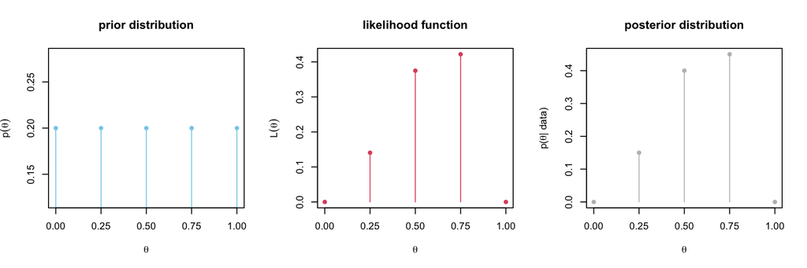

   ```r
   par(mfrow=c(1,3))

   # plot the prior
   plot(theta, prior, type="h", xaxt="n",
        ylab = expression(p(theta)), xlab = expression(theta),
        main = "prior distribution", col = "skyblue")
   points(theta, prior, pch = 16, col = "skyblue")
   axis(1, at=theta)

   # plot the likelihood
   plot(theta, likelihood, type="h", xaxt="n",
        ylab = expression(L(theta)), xlab = expression(theta),
        main = "likelihood function", col = 2)
   points(theta, likelihood, pch = 16, col = 2)
   axis(1, at=theta)

   # plot the normalized posterior
   plot(theta, posterior, type="h", xaxt="n",
        ylab = expression("p("*theta*"| data)"),
        xlab = expression(theta),
        main = "posterior distribution", col = "gray")
   points(theta, posterior, pch = 16, col = "gray")
   axis(1, at=theta)
   ```

   Plotting these all on a single graph (and scaling the likelihood such that the height of the bars sum to 1[^2]) we get:

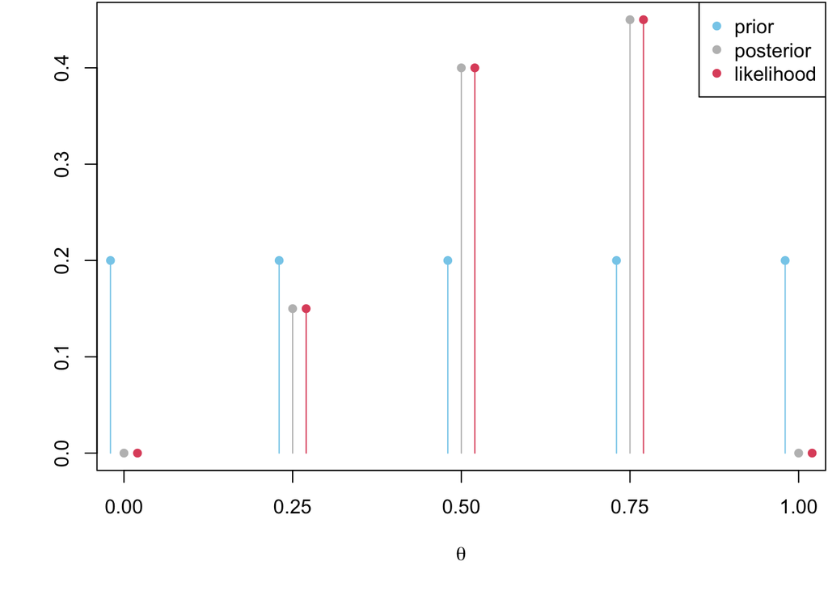

   ```r
   eps = 0.02

   par(mar=c(5,4,0,0) + 0.1)
   # plot the normalized posterior
   plot(theta, posterior, type="h",
        ylab = "", xlab = expression(theta),
        main = "", col = "gray", xaxt="n",
        ylim=c(0, max(c(likelihood, prior, posterior))))
   points(theta, posterior, pch = 16, col = "gray")
   axis(1, at=theta)
   legend("topright", c("prior", "posterior", "likelihood"), pch = 16, col = c("skyblue", "gray",2))


   # plot the scaled likelihood
   likelihood = likelihood/sum(likelihood)
   lines(theta+eps, likelihood, type="h", col = 2)
   points(theta+eps, likelihood, pch = 16, col = 2)

   # plot the prior pmf
   lines(theta-eps, prior, type="h", col = "skyblue")
   points(theta-eps, prior, pch = 16, col = "skyblue")
   ```

### Bayesian Updating

4. Now suppose we are allowed to take another sample of six balls with replacement and we obtain the following: {R,R,W,W,R,W}. Perform Bayesian updating by using completing the following Bayesian table using the the posterior from the previous study as the prior in our current study.

   | Support | Prior | Likelihood | Posterior |
   | --- | --- | --- | --- |
   | $\dots$ | $\dots$ | $\dots$ | $\dots$ |

   **Solution (click to view)**

   Knowing now that $\theta= 1$ and $\theta=0$ are impossible (since we know there is at least one red and whiteball), we can express our prior PMF as

   ```r
   theta <- theta[2:4]
   prior <- posterior[2:4]
   tab = rbind(theta, prior)
   rownames(tab) = c("theta", "p(theta)")
   kable(tab, digits = 3)
   ```

   |  | RWWW | RRWW | RRRW |
   | --- | --- | --- | --- |
   | theta | 0.25 | 0.5 | 0.75 |
   | p(theta) | 0.15 | 0.4 | 0.45 |

   Computing our new likelihood function is similar to our first study, only now $n = 6$ and $x = 3$.

   $$\begin{align}L(\theta) &= {n \choose x} \theta^x (1-\theta)^{n-x} & \text{for } x \in 0, ..., n\\L(0.25) &= {6 \choose 3} 0.25^3 (1-0.25)^{6-3} = 0.1318359 \\L(0.50) &= {6 \choose 3} 0.50^3 (1-0.5)^{6-3} = 0.3125 \\L(0.75) &= {6 \choose 3} 0.75^3 (1-0.75)^{6-3} = 0.1318359 \\\end{align}$$

   And using the `dbinom()` function:

   ```r
   likelihood <- dbinom(3, size = 6, prob = theta, log=FALSE)
   likelihood
   ```

   ```
   [1] 0.1318359 0.3125000 0.1318359
   ```

   To obtain the posterior we simply multiply the prior times the likelihood and scale such the probabilities add to 1.

   ```r
   (posterior <- prior*likelihood)                 # unnormalized posterior
   ```

   ```
         RWWW       RRWW       RRRW
   0.01977539 0.12500000 0.05932617
   ```

   ```r
   (posterior <- posterior/sum(posterior))         # normalized posterior
   ```

   ```
         RWWW       RRWW       RRRW
   0.09688995 0.61244019 0.29066986
   ```

   The updated Bayesian table is summarized below in

   Table 1

   |  | theta | prior | likelihood | posterior |
   | --- | --- | --- | --- | --- |
   | RWWW | 0.25 | 0.15 | 0.1318359375 | 0.09688995215311 |
   | RRWW | 0.5 | 0.4 | 0.3125 | 0.61244019138756 |
   | RRRW | 0.75 | 0.45 | 0.1318359375 | 0.29066985645933 |
   | totals | – | 1 | 0.576171875 | 1 |

   An example of a Bayesian table after observing {R,R,W,W,R,W}.

   In a similar way we can plot these distributions

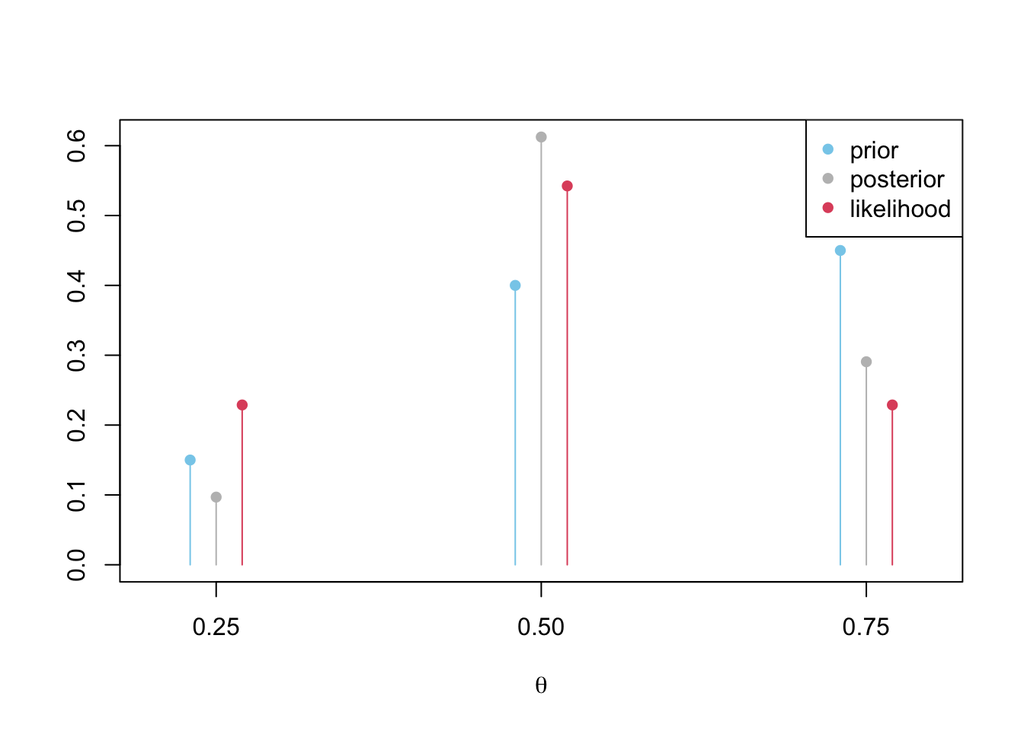

   ```r
   eps = 0.02

   # plot the normalized posterior
   plot(theta, posterior, type="h",
        ylab = "", xlab = expression(theta),
        main = "", col = "gray", xaxt="n",
        xlim = c(0.2,0.8),
        ylim=c(0, max(c(likelihood, prior, posterior))))
   points(theta, posterior, pch = 16, col = "gray")
   axis(1, at=theta)
   legend("topright", c("prior", "posterior", "likelihood"), pch = 16, col = c("skyblue", "gray",2))


   # plot the scaled likelihood
   likelihood = likelihood/sum(likelihood)
   lines(theta+eps, likelihood, type="h", col = 2)
   points(theta+eps, likelihood, pch = 16, col = 2)

   # plot the prior pmf
   lines(theta-eps, prior, type="h", col = "skyblue")
   points(theta-eps, prior, pch = 16, col = "skyblue")
   ```

5. Recall that in the frequentist framework, we have an MLE (maximum likelihood estimator) which corresponds to the parameter value that maximizes the likelihood function. Likewise in the Bayesian framework we have MAP (Maximum A Posteriori) estimation which corresponds to the parameter value that maximizes the posterior. Using this updated posterior distribution, what is the MAP estimate?

   **Solution (click to view)**

   The posterior is largest for $\theta = 0.5$. so our MAP estimate, sometimes denoted $\theta_{MAP} = 0.5$

### Exchangibility

Notice that had we had all of the data in “one batch” as opposed to two batches, we would have obtained the same posterior. Verify this.

**Solution (click to view)**

We will start with the original prior

```r
theta = c(0,0.25,0.5,0.75,1.0)
prior <- rep(1/length(theta), length(theta))
names(prior) <- theta
```

|  | 0 | 0.25 | 0.5 | 0.75 | 1 |
| --- | --- | --- | --- | --- | --- |
| theta | 0.0 | 0.25 | 0.5 | 0.75 | 1.0 |
| p(theta | 0.2 | 0.20 | 0.2 | 0.20 | 0.2 |

The likelihood can now be modeled by a binomial with $n = 3 + 6 = 9$ and $x = 2 + 3 = 5$:

$$\begin{align}L(\theta) &= {n \choose x} \theta^x (1-\theta)^{n-x} & \text{for } x \in 0, ..., n\\L(0) &= {9 \choose 5} 0^4 (1-0)^{9-5} = 0 \\L(0.25) &= {9 \choose 5} 0.25^4 (1-0.25)^{9-5} = 0.0389328 \\L(0.50) &= {9 \choose 5} 0.50^4 (1-0.5)^{9-5} = 0.2460938 \\L(0.75) &= {9 \choose 5} 0.75^4 (1-0.75)^{9-5} = 0.1167984 \\L(1.00) &= {9 \choose 5} 1.00^4 (1-1)^{9-5} = 0 \\\end{align}$$

Or by using the `bdinom()` function:

```r
(likelihood <- dbinom(5, size = 9, prob = theta, log=FALSE))
```

```
[1] 0.0000000 0.0389328 0.2460938 0.1167984 0.0000000
```

Multiplying the prior by the likelihood and normalizing we get the following Bayesian table which is identical to the one obtained in Table 1 from the Bayesian Updating section:

```r
posterior <- prior*likelihood                 # unnormalized posterior
posterior <- posterior/sum(posterior)         # normalized posterior
posterior
```

```
         0       0.25        0.5       0.75          1
0.00000000 0.09688995 0.61244019 0.29066986 0.00000000
```

Summarizing in a table

|  | theta | prior | likelihood | posterior |
| --- | --- | --- | --- | --- |
| WWWW | 0.00 | 0.2 | 0.000 | 0.000 |
| RWWW | 0.25 | 0.2 | 0.039 | 0.097 |
| RRWW | 0.50 | 0.2 | 0.246 | 0.612 |
| RRRW | 0.75 | 0.2 | 0.117 | 0.291 |
| RRRR | 1.00 | 0.2 | 0.000 | 0.000 |
| Totals | NA | 1.0 | 0.402 | 1.000 |

## Simulation

```r
n = 9
x = 5
reps = 10000
```

To gain some additional insight into the Bayesian framework, let’s simulate 10000 random instance of this experiment. To begin, we’ll set up the possible values of $\theta$ and the corresponding prior model $p(\theta$):

```r
support.theta = c(0,0.25,0.5,0.75,1)  # possible values of theta
prior = c(1/5,1/5,1/5,1/5,1/5)        # prior probabilities
```

Next, we simulate 10,000 possible outcomes of $\theta$ from the prior model:

```r
# Simulate 'reps' values of theta from the prior
# where 'reps' = the number of independent samples
set.seed(84735)
theta = sample(support.theta, size = reps, prob = prior, replace = TRUE)
```

From each of the 10000 prior plausible values $\theta$, we can simulate selecting `n` balls and recording $y$, the number where are red. Since the dependence of $y$ on $\theta$ follows a Binomial model, we can directly simulate y using the `rbinom()` function with `size` = `n` = 9 and `prob =` $\theta$.

```r
# where n is the total number of balls taken with replacement
y = rbinom(reps, size = n, prob = theta)
```

Let’s store the results in a data frame:

```r
balls_sim = data.frame(theta, y)
head(balls_sim)
```

```
  theta y
1  1.00 9
2  1.00 9
3  0.75 7
4  0.00 0
5  1.00 9
6  0.50 4
```

The combined 10000 simulated $\theta$ values closely approximate the uniform prior model:

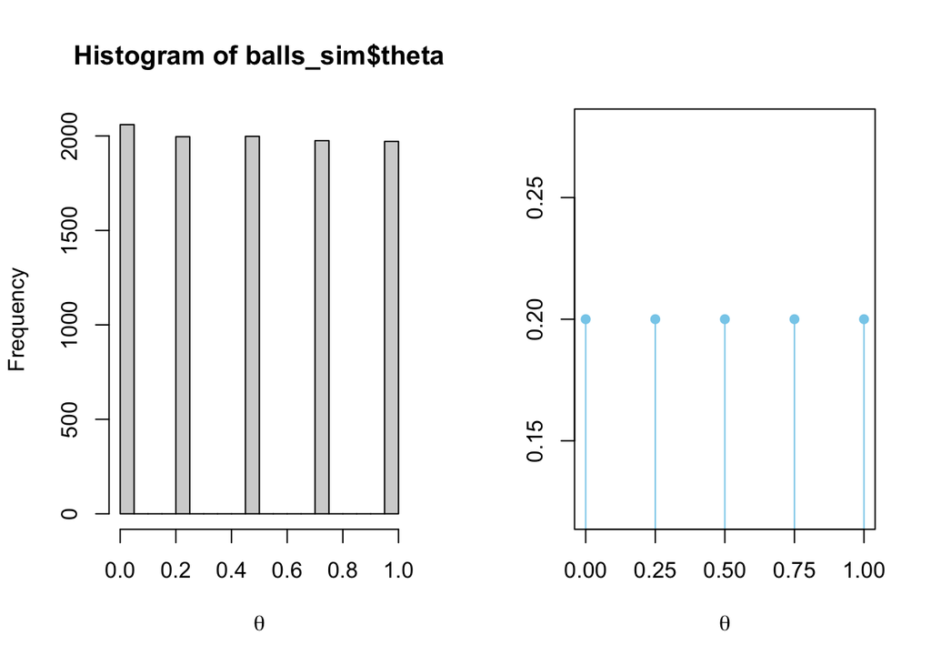

```r
par(mfrow=c(1,2))
hist(balls_sim$theta, xlab=expression(theta))

plot(support.theta, prior, type="h",
     ylab = "", xlab = expression(theta),
     main = "", col = "skyblue", xaxt="n")
points(support.theta, prior, pch = 16, col = "skyblue")
axis(1, at=support.theta)
```

Further, the 10000 simulated $y$’s illuminate the dependence of these outcomes on the value of $\theta$:

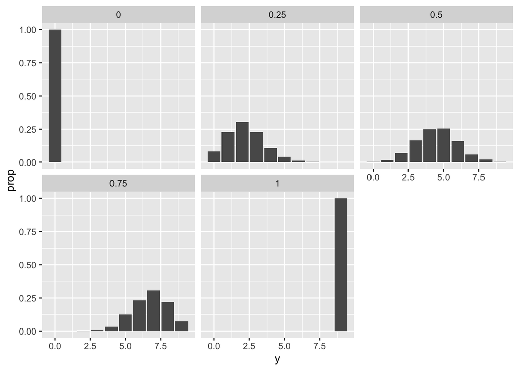

**Figure caption**: A bar plot of simulated number of red balls y under each possible binomial proportion $\theta$

```r
ggplot(balls_sim, aes(x = y)) +
  stat_count(aes(y = after_stat(prop))) +
  facet_wrap(~ theta)
```

The above closely mimics the conditional pmfs $p(y\mid \theta)$:

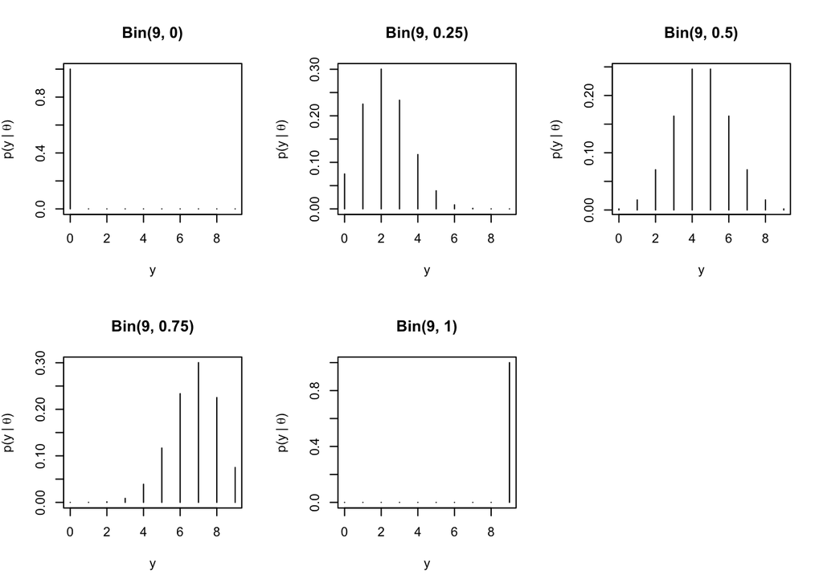

Figure 1: the conditional pmfs and thus the random outcomes of Y, under each possible value of $\theta$

```r
par(mfrow=c(2,3))

support.y = 0:n
for (i in 1:length(support.theta)){
plot(support.y, dbinom(support.y, size = n, prob = support.theta[i]),
     type="h", xlab = "y",
     ylab=expression("p(y | "*theta*")"),
     main = paste("Bin(", n, ", ", support.theta[i], ")",sep=""))
}
```

```r
tab = table(balls_sim)
four_red = tab[,"4"]
tab = rbind(tab, colSums(tab))
kbl(tab) %>%
   kable_paper(full_width = F) %>%
  column_spec(7, bold = T)
```

|  | 0 | 1 | 2 | 3 | 4 | 5 | 6 | 7 | 8 | 9 |
| --- | --- | --- | --- | --- | --- | --- | --- | --- | --- | --- |
| 0 | 2060 | 0 | 0 | 0 | 0 | 0 | 0 | 0 | 0 | 0 |
| 0.25 | 161 | 457 | 604 | 457 | 211 | 80 | 20 | 6 | 0 | 0 |
| 0.5 | 7 | 27 | 141 | 333 | 500 | 512 | 319 | 117 | 38 | 4 |
| 0.75 | 0 | 0 | 3 | 21 | 60 | 246 | 456 | 609 | 436 | 144 |
| 1 | 0 | 0 | 0 | 0 | 0 | 0 | 0 | 0 | 0 | 1971 |
|  | 2228 | 484 | 748 | 811 | 771 | 838 | 795 | 732 | 474 | 2119 |

Plotting these we get:

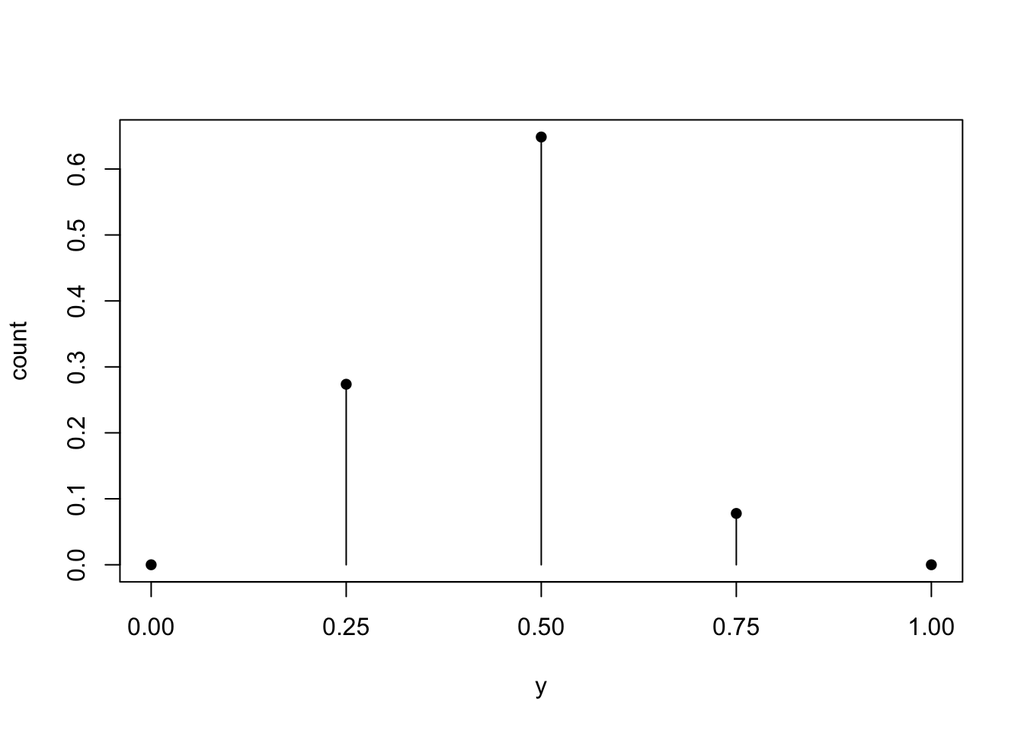

```r
plot(support.theta, four_red/sum(four_red),
     type="h", xaxt="n", xlab = "y",
     ylab="count")
points(support.theta, four_red/sum(four_red), pch = 16)
axis(1, at=support.theta)
```

## Resources

- Bertsekas, D.P., Tsitsiklis, J.N. (2008). Introduction to Probability. United States: Athena Scientific.
- Lynch, S. M. (2007). Introduction to Applied Bayesian Statistics and Estimation for Social Scientists. Germany: Springer New York.

## Footnotes

[^1]: As we will discuss later in the module, this decrease in uncertain holds true only in expectation
[^2]: we do this in order for the likelihood to be on the same scale asthe prior and posterior